# Challenge B

Luisa Van der Ploeg & Arthur Biamouret

5 décembre 2017

You can find all the data and the documents on github, just click [here](https://github.com/arthurbiamouret?tab=repositories).

## Task 1B - Predicting house prices in Ames, Iowa (continued)

We first download all the packages needed for the Task 1B.

```r
library(tidyverse)
library(randomForest)
```

We open the data that we are going to use in this task.

```r
train <- read.csv(file.choose(), header = T, dec = ".")
test <- read.csv(file.choose(), header = T, dec = ".")
```

We take out all the missing data from our training data using the code of the correction of challenge A.

```r
train %>% summarise_all(.funs = funs(sum(is.na(.)))) %>% gather(key = "feature", value = "missing.observations") %>% filter(missing.observations > 0)
```

```
##         feature missing.observations
## 1   LotFrontage                  259
## 2         Alley                 1369
## 3    MasVnrType                    8
## 4    MasVnrArea                    8
## 5      BsmtQual                   37
## 6      BsmtCond                   37
## 7  BsmtExposure                   38
## 8  BsmtFinType1                   37
## 9  BsmtFinType2                   38
## 10   Electrical                    1
## 11  FireplaceQu                  690
## 12   GarageType                   81
## 13  GarageYrBlt                   81
## 14 GarageFinish                   81
## 15   GarageQual                   81
## 16   GarageCond                   81
## 17       PoolQC                 1453
## 18        Fence                 1179
## 19  MiscFeature                 1406
```

```r
remove.vars <- train %>% summarise_all(.funs = funs(sum(is.na(.)))) %>% gather(key = "feature", value = "missing.observations") %>% filter(missing.observations > 100) %>% select(feature) %>% unlist

train <- train %>% select(- one_of(remove.vars))

train %>% summarise_all(.funs = funs(sum(is.na(.)))) %>% gather(key = "feature", value = "missing.observations") %>% filter(missing.observations > 0)
```

```
##         feature missing.observations
## 1    MasVnrType                    8
## 2    MasVnrArea                    8
## 3      BsmtQual                   37
## 4      BsmtCond                   37
## 5  BsmtExposure                   38
## 6  BsmtFinType1                   37
## 7  BsmtFinType2                   38
## 8    Electrical                    1
## 9    GarageType                   81
## 10  GarageYrBlt                   81
## 11 GarageFinish                   81
## 12   GarageQual                   81
## 13   GarageCond                   81
```

```r
train <- train %>% filter(is.na(GarageType) == FALSE, is.na(MasVnrType) == FALSE, is.na(BsmtFinType2) == FALSE, is.na(BsmtExposure) == FALSE, is.na(Electrical) == FALSE)

train %>% summarise_all(.funs = funs(sum(is.na(.)))) %>% gather(key = "feature", value = "missing.observations") %>% filter(missing.observations > 0)
```

```
## [1] feature              missing.observations
## <0 rows> (or 0-length row.names)
```

Our training data is now cleaned.

#### Step 1: *Choose a ML technique : non-parametric kernel estimation, random forests, etc. . . Give a brief intuition of how it works. (1 points)*

**Random forest** is a method that uses multiple learning algorithms to obtain better predictive performance than could be obtained from one of the learning algorithms alone. It is a method that operate by constructing multiple decision trees and giving the class (classification or regression) of each tree. It is usefull to correct for decision trees’ habit of overfitting to their training set. It does several independant models and calculte the mean of all of them in order to reduce the forecast error made when we do regression. This is why the more trees there are, the better the result.

#### Step 2: *Train the chosen technique on the training data. Hint : packages np for non-parametric regressions, randomForest for random forests. Don’t use the variable Id as a feature. (2 points)*

Here we train Random forest on our training data. Thanks to this technique we can look at the importance of each variables in those predictions.

```r
M1 <- randomForest(train$SalePrice ~ .-Id, data = train)
print(M1)
```

```
##
## Call:
##  randomForest(formula = train$SalePrice ~ . - Id, data = train)
##                Type of random forest: regression
##                      Number of trees: 500
## No. of variables tried at each split: 24
##
##           Mean of squared residuals: 814915819
##                     % Var explained: 86.9
```

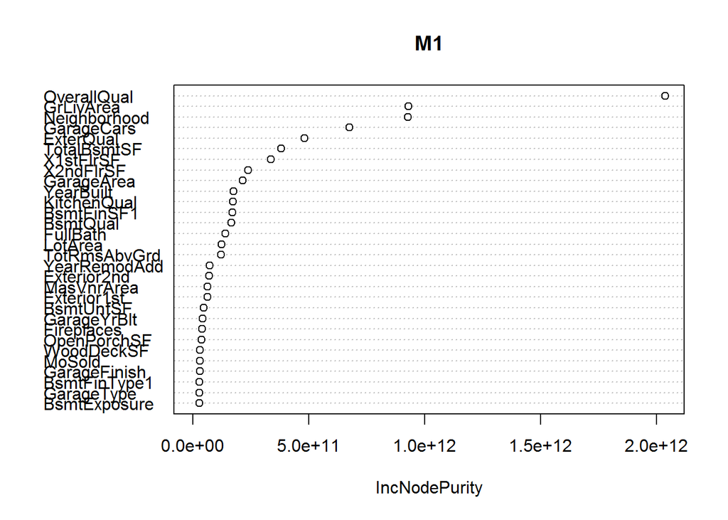

```r
varImpPlot(M1)
```

```r
M1$importance
```

```
##               IncNodePurity
## MSSubClass     1.456733e+10
## MSZoning       1.977762e+10
## LotArea        1.230513e+11
## Street         1.198948e+08
## LotShape       1.245154e+10
## LandContour    1.483412e+10
## Utilities      1.926514e+07
## LotConfig      1.312101e+10
## LandSlope      5.058663e+09
## Neighborhood   9.273561e+11
## Condition1     9.566193e+09
## Condition2     2.829565e+09
## BldgType       5.116731e+09
## HouseStyle     2.318939e+10
## OverallQual    2.038020e+12
## OverallCond    2.630307e+10
## YearBuilt      1.738641e+11
## YearRemodAdd   7.150434e+10
## RoofStyle      8.088374e+09
## RoofMatl       5.159843e+09
## Exterior1st    6.171573e+10
## Exterior2nd    6.848774e+10
## MasVnrType     1.165075e+10
## MasVnrArea     6.333062e+10
## ExterQual      4.806871e+11
## ExterCond      4.513049e+09
## Foundation     1.524044e+10
## BsmtQual       1.648220e+11
## BsmtCond       3.692996e+09
## BsmtExposure   2.684606e+10
## BsmtFinType1   2.723367e+10
## BsmtFinSF1     1.695931e+11
## BsmtFinType2   5.625553e+09
## BsmtFinSF2     4.782146e+09
## BsmtUnfSF      4.629669e+10
## TotalBsmtSF    3.809229e+11
## Heating        1.270511e+09
## HeatingQC      9.343740e+09
## CentralAir     5.915819e+09
```

[output cut: 19 more lines]

```
## GarageArea     2.139696e+11
## GarageQual     2.987527e+09
## GarageCond     1.145165e+09
## PavedDrive     1.952457e+09
## WoodDeckSF     3.076409e+10
## OpenPorchSF    3.740124e+10
## EnclosedPorch  6.158034e+09
## X3SsnPorch     1.824997e+09
## ScreenPorch    1.062057e+10
## PoolArea       6.186021e+09
## MiscVal        7.298839e+08
## MoSold         2.901552e+10
## YrSold         1.136845e+10
## SaleType       1.111426e+10
## SaleCondition  1.456124e+10
```

#### Step 3: *Make predictions on the test data, and compare them to the predictions of a linear regression of your choice. (2 points)*

We first start by removing all the missing values in our testing data using exactly the same method as the one for the training data.

```r
remove.vars <- test %>% summarise_all(.funs = funs(sum(is.na(.)))) %>% gather(key = "feature", value = "missing.observations") %>% filter(missing.observations > 100) %>% select(feature) %>% unlist

test <- test %>% select(- one_of(remove.vars))

test %>% summarise_all(.funs = funs(sum(is.na(.)))) %>% gather(key = "feature", value = "missing.observations") %>% filter(missing.observations > 0)
```

```
##         feature missing.observations
## 1      MSZoning                    4
## 2     Utilities                    2
## 3   Exterior1st                    1
## 4   Exterior2nd                    1
## 5    MasVnrType                   16
## 6    MasVnrArea                   15
## 7      BsmtQual                   44
## 8      BsmtCond                   45
## 9  BsmtExposure                   44
## 10 BsmtFinType1                   42
## 11   BsmtFinSF1                    1
## 12 BsmtFinType2                   42
## 13   BsmtFinSF2                    1
## 14    BsmtUnfSF                    1
## 15  TotalBsmtSF                    1
## 16 BsmtFullBath                    2
## 17 BsmtHalfBath                    2
## 18  KitchenQual                    1
## 19   Functional                    2
## 20   GarageType                   76
## 21  GarageYrBlt                   78
## 22 GarageFinish                   78
## 23   GarageCars                    1
## 24   GarageArea                    1
## 25   GarageQual                   78
## 26   GarageCond                   78
## 27     SaleType                    1
```

```r
test <- test %>% filter(is.na(GarageType) == FALSE, is.na(MasVnrType) == FALSE, is.na(BsmtFinType2) == FALSE, is.na(BsmtExposure) == FALSE, is.na(Electrical) == FALSE, is.na(MSZoning) == FALSE, is.na(Utilities) == FALSE, is.na(BsmtQual) == FALSE, is.na(BsmtCond) == FALSE, is.na(KitchenQual) == FALSE, is.na(Functional) == FALSE, is.na(GarageYrBlt) == FALSE, is.na(GarageFinish) == FALSE, is.na(GarageCars) == FALSE, is.na(GarageArea) == FALSE,is.na(GarageQual) == FALSE, is.na(GarageCond) == FALSE, is.na(SaleType) == FALSE)

test %>% summarise_all(.funs = funs(sum(is.na(.)))) %>% gather(key = "feature", value = "missing.observations") %>% filter(missing.observations > 0)
```

```
## [1] feature              missing.observations
## <0 rows> (or 0-length row.names)
```

Because the function *random forest* is not confortable with the differences in levels, we need to adjust the levels of some variables between our training and our testing data. We adjust the testing data to the training one because the levels are always higher in the training one. We can do that using the function *levels*.

```r
levels(test$Utilities) <- levels(train$Utilities)
levels(test$Condition2) <- levels(train$Condition2)
levels(test$HouseStyle) <- levels(train$HouseStyle)
levels(test$RoofMatl) <- levels(train$RoofMatl)
levels(test$Exterior1st) <- levels(train$Exterior1st)
levels(test$Exterior2nd) <- levels(train$Exterior2nd)
levels(test$Electrical) <- levels(train$Electrical)
levels(test$GarageQual) <- levels(train$GarageQual)
levels(test$Heating) <- levels(train$Heating)
```

Then we do our predictions using the function *predict*.

```r
prediction2 <- data.frame(Id = test$Id, SalePrice_predict = predict(M1, test, type="response"))
write.csv(x = prediction2, file = "predictions2.csv", na = "NA", quote = FALSE, row.names = FALSE)

summary(prediction2)
```

```
##        Id       SalePrice_predict
##  Min.   :1461   Min.   : 79009
##  1st Qu.:1816   1st Qu.:138187
##  Median :2182   Median :167588
##  Mean   :2185   Mean   :184828
##  3rd Qu.:2548   3rd Qu.:212526
##  Max.   :2919   Max.   :486301
```

To compare our predictions to the ones of the linear regression, we do exactly the same model as the one made in the correction of challenge A. We use this model to do our predictions.

```r
lm_model_2 <- lm(SalePrice ~ MSZoning + LotArea + Neighborhood  + YearBuilt + OverallQual, data = train)

prediction <- data.frame(Id = test$Id, SalePrice_predict = predict(lm_model_2, test, type="response"))
write.csv(x = prediction, file = "predictions.csv", na = "NA", quote = FALSE, row.names = FALSE)

summary(prediction)
```

```
##        Id       SalePrice_predict
##  Min.   :1461   Min.   : 11634
##  1st Qu.:1816   1st Qu.:135501
##  Median :2182   Median :171403
##  Mean   :2185   Mean   :184924
##  3rd Qu.:2548   3rd Qu.:215647
##  Max.   :2919   Max.   :391638
```

To compare them together, we plot them on a same graph.

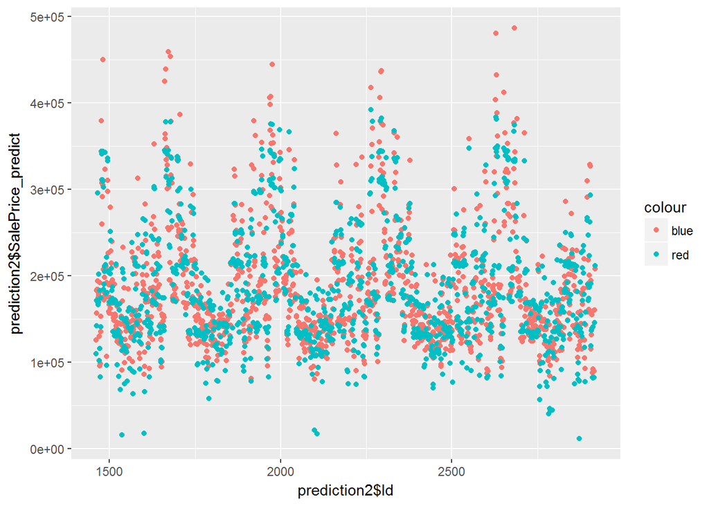

```r
ggplot()+geom_point(mapping = aes(x=prediction2$Id, y=prediction2$SalePrice_predict, colour="blue"))+
  geom_point(mapping = aes(x=prediction$Id, y=prediction$SalePrice_predict, colour="red"))
```

## Task 2 A - Overfitting in Machine Learning (continued)

We start by uploading the packages needed for this task.

```r
library(np)
library(caret)
library(tidyverse)
```

We will use the same data as in challenge A. This is why we create them in exactly the same way (by taking the same code as the one of the challenge A’s correction).

```r
set.seed(1)
Nsim <- 150
b <- c(0,1)
x0 <- rep(1, Nsim)
x1 <- rnorm(n = Nsim)

X <- cbind(x0, x1^3)
y.true <- X %*% b

eps <- rnorm(n = Nsim)
y <- X %*% b + eps

df <- tbl_df(y[,1]) %>% rename(y = value) %>% bind_cols(tbl_df(x1)) %>% rename(x = value) %>% bind_cols(tbl_df(y.true[,1])) %>% rename(y.true = value)

training.index <- createDataPartition(y = y, times = 1, p = 0.8)
df <- df %>% mutate(which.data = ifelse(1:n() %in% training.index$Resample1, "training", "test"))

training <- df %>% filter(which.data == "training")
training <- data.frame(training)
test <- df %>% filter(which.data == "test")
test <- data.frame(test)
```

#### Step 1: *Estimate a low-flexibility local linear model on the training data. For that, you can use function npreg the package np. Choose ll for the method (local linear), and a bandwidth of 0.5; Call this model ll.fit.lowflex*

```r
ll.fit.lowflex <- npreg(y ~ x, bws = 0.5, method="ll", data=training)
```

#### Step 2: *Estimate a high-flexibility local linear model on the training data. For that, you can use function npreg the package np. Choose ll for the method (local linear), and a bandwidth of 0.01; Call this model ll.fit.highflex*

```r
ll.fit.highflex <- npreg(y ~ x, bws = 0.01, method="ll", data=training)
```

#### Step 3: *Plot the scatterplot of x-y, along with the predictions of ll.fit.lowflex and ll.fit.highflex, on only the training data. See Figure 1.*

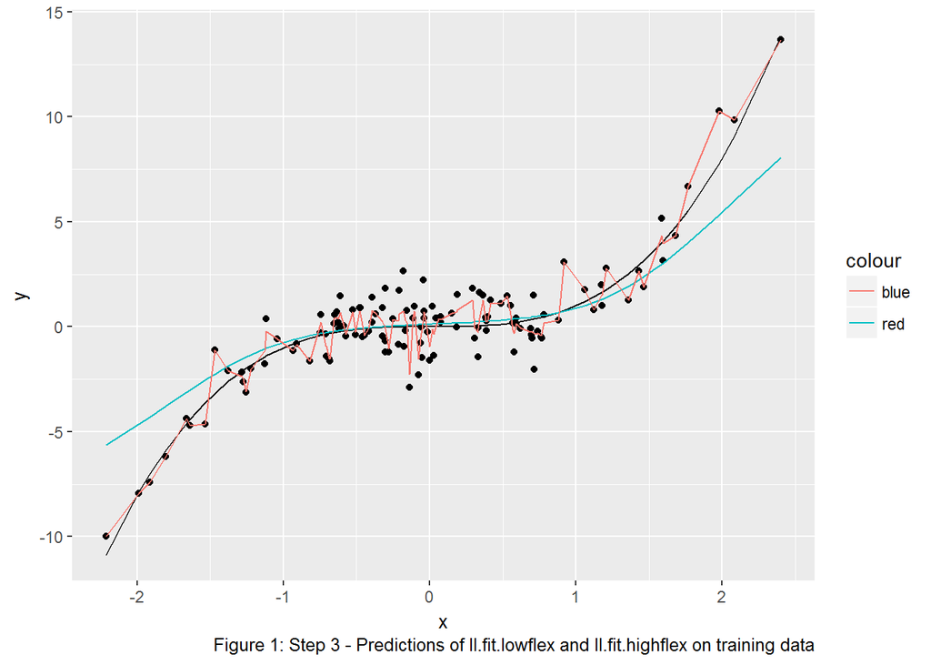

```r
training <- training %>% mutate(y.ll.lowflex = predict(object = ll.fit.lowflex, newdata = training), y.ll.highflex = predict(object = ll.fit.highflex, newdata = training))

ggplot(training) + geom_point(mapping = aes(x = x, y = y))+geom_line(mapping = aes(x = x, y = y.true))+
  geom_line(mapping = aes(x = x, y=y.ll.lowflex, col="red"))+
  geom_line(mapping = aes(x=x, y=y.ll.highflex, col="blue"))+
  labs(x="x",y="y",caption="Figure 1: Step 3 - Predictions of ll.fit.lowflex and ll.fit.highflex on training data")
```

#### Step 4: *Between the two models, which predictions are more variable? Which predictions have the least bias?*

```r
var(training$y.ll.lowflex)
```

```
## [1] 2.764222
```

```r
var(training$y.ll.highflex)
```

```
## [1] 7.569123
```

```r
var(training$y)
```

```
## [1] 8.088941
```

```r
mean(training$y.ll.lowflex)
```

```
## [1] 0.1190046
```

```r
mean(training$y.ll.highflex)
```

```
## [1] 0.1255062
```

```r
mean(training$y)
```

```
## [1] 0.1257877
```

The y.ll.lowflex has the smallest variance but its mean is not as close from y as the mean of y.ll.highflex. This means that y.ll.highflex is the one with the smallest bias. The lowflex prediction is the one with the lowest variance but the highflex is the one with the lowest bias. We can see it on the graph: the lowflex predictions form a smooth line while the highflex ones are more disperced. But the highflex predictions are closer from the values of y, this is why it has the lowest bias.

#### Step 5: *Plot the scatterplot of x-y, along with the predictions of ll.fit.lowflex and ll.fit.highflex now using the test data. Which predictions are more variable? What happened to the bias of the least biased model?*

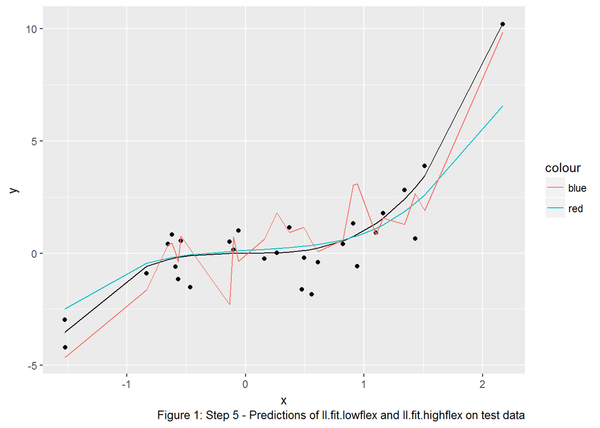

```r
test <- test %>% mutate(yt.ll.lowflex = predict(object = ll.fit.lowflex, newdata = test), yt.ll.highflex = predict(object = ll.fit.highflex, newdata = test))

ggplot(test) + geom_point(mapping = aes(x = x, y = y))+geom_line(mapping = aes(x = x, y = y.true))+
  geom_line(mapping = aes(x = x, y=yt.ll.lowflex, col="red"))+
  geom_line(mapping = aes(x=x, y=yt.ll.highflex, col="blue"))+
  labs(x="x",y="y",caption="Figure 1: Step 5 - Predictions of ll.fit.lowflex and ll.fit.highflex on test data")
```

```r
var(test$yt.ll.lowflex)
```

```
## [1] 2.572402
```

```r
var(test$yt.ll.highflex)
```

```
## [1] 6.582451
```

```r
var(test$y)
```

```
## [1] 6.350704
```

```r
mean(test$yt.ll.lowflex)
```

```
## [1] 0.4873629
```

```r
mean(test$yt.ll.highflex)
```

```
## [1] 0.6952806
```

```r
mean(test$y)
```

```
## [1] 0.3689167
```

The yt.ll.highflex is still the one that fluctuates the most. When we look at the means, the bias of the highflex predictions has increased a lot and now the lowflex predictions are the ones with less bias.

#### Step 6: *Create a vector of bandwidth going from 0.01 to 0.5 with a step of 0.001*

```r
band <- seq(0.01, 0.5, by = 0.001)
```

#### Step 7: *Estimate a local linear model y ~ x on the training data with each bandwidth.*

```r
llmodel <- lapply(X = band, FUN = function(band) {npreg(y ~ x, data = training, method = "ll", bws = band)})
```

#### Step 8: *Compute for each bandwidth the MSE on the training data.*

```r
MSEtraining <- function(fit.model){
  predi <- predict(object = fit.model, newdata = training)
  training %>% mutate(sqrderr = (y - predi)^2) %>% summarize(mse = mean(sqrderr))
}
MSET <- unlist(lapply(X = llmodel, FUN = MSEtraining))
MSET
```

```
##       mse       mse       mse       mse       mse       mse       mse
## 0.3460818 0.3708529 0.3947976 0.4181274 0.4408973 0.4630605 0.4845110
##       mse       mse       mse       mse       mse       mse       mse
## 0.5051165 0.5247438 0.5432788 0.5606400 0.5767855 0.5917133 0.6054576
##       mse       mse       mse       mse       mse       mse       mse
## 0.6180814 0.6296688 0.6403162 0.6501252 0.6591967 0.6676263 0.6755010
##       mse       mse       mse       mse       mse       mse       mse
## 0.6828973 0.6898806 0.6965051 0.7028144 0.7088429 0.7146168 0.7201557
##       mse       mse       mse       mse       mse       mse       mse
## 0.7254743 0.7305835 0.7354915 0.7402053 0.7447307 0.7490737 0.7532403
##       mse       mse       mse       mse       mse       mse       mse
## 0.7572372 0.7610717 0.7647515 0.7682851 0.7716815 0.7749502 0.7781005
##       mse       mse       mse       mse       mse       mse       mse
## 0.7811423 0.7840851 0.7869382 0.7897108 0.7924116 0.7950487 0.7976296
##       mse       mse       mse       mse       mse       mse       mse
## 0.8001614 0.8026504 0.8051023 0.8075222 0.8099143 0.8122826 0.8146301
##       mse       mse       mse       mse       mse       mse       mse
## 0.8169595 0.8192729 0.8215720 0.8238580 0.8261316 0.8283935 0.8306439
##       mse       mse       mse       mse       mse       mse       mse
## 0.8328828 0.8351100 0.8373250 0.8395275 0.8417169 0.8438925 0.8460537
##       mse       mse       mse       mse       mse       mse       mse
## 0.8481998 0.8503301 0.8524439 0.8545407 0.8566197 0.8586806 0.8607228
##       mse       mse       mse       mse       mse       mse       mse
## 0.8627459 0.8647496 0.8667335 0.8686975 0.8706414 0.8725650 0.8744685
##       mse       mse       mse       mse       mse       mse       mse
## 0.8763517 0.8782147 0.8800578 0.8818809 0.8836845 0.8854686 0.8872337
##       mse       mse       mse       mse       mse       mse       mse
## 0.8889799 0.8907078 0.8924176 0.8941097 0.8957845 0.8974425 0.8990842
##       mse       mse       mse       mse       mse       mse       mse
## 0.9007099 0.9023202 0.9039155 0.9054964 0.9070632 0.9086165 0.9101567
##       mse       mse       mse       mse       mse       mse       mse
## 0.9116844 0.9132001 0.9147042 0.9161972 0.9176797 0.9191520 0.9206147
##       mse       mse       mse       mse       mse       mse       mse
## 0.9220683 0.9235132 0.9249498 0.9263787 0.9278003 0.9292150 0.9306233
##       mse       mse       mse       mse       mse       mse       mse
## 0.9320256 0.9334223 0.9348138 0.9362006 0.9375830 0.9389615 0.9403364
##       mse       mse       mse       mse       mse       mse       mse
## 0.9417081 0.9430770 0.9444435 0.9458079 0.9471705 0.9485317 0.9498918
##       mse       mse       mse       mse       mse       mse       mse
## 0.9512512 0.9526101 0.9539690 0.9553280 0.9566875 0.9580477 0.9594090
```

[output cut: 87 more lines]

```
## 1.8271723 1.8320500 1.8369410 1.8418452 1.8467626 1.8516932 1.8566369
##       mse       mse       mse       mse       mse       mse       mse
## 1.8615937 1.8665636 1.8715465 1.8765424 1.8815513 1.8865730 1.8916076
##       mse       mse       mse       mse       mse       mse       mse
## 1.8966550 1.9017152 1.9067881 1.9118737 1.9169720 1.9220828 1.9272062
##       mse       mse       mse       mse       mse       mse       mse
## 1.9323421 1.9374905 1.9426513 1.9478244 1.9530099 1.9582076 1.9634175
##       mse       mse       mse       mse       mse       mse       mse
## 1.9686396 1.9738738 1.9791201 1.9843783 1.9896486 1.9949307 2.0002247
##       mse       mse       mse       mse       mse       mse       mse
## 2.0055305 2.0108480 2.0161772 2.0215181 2.0268705 2.0322344 2.0376098
##       mse       mse       mse       mse       mse       mse       mse
## 2.0429966 2.0483948 2.0538042 2.0592248 2.0646566 2.0700996 2.0755535
##       mse
## 2.0810184
```

#### Step 9: *Compute for each bandwidth the MSE on the test data.*

```r
MSEtest <- function(fit.model){
  predi <- predict(object = fit.model, newdata = test)
  test %>% mutate(sqrderr = (y - predi)^2) %>% summarize(mse = mean(sqrderr))
}
MSETEST <- unlist(lapply(X = llmodel, FUN = MSEtest))
MSETEST
```

```
##       mse       mse       mse       mse       mse       mse       mse
## 2.2572777 2.1896544 2.1268625 2.0712311 2.0233086 1.9825734 1.9479119
##       mse       mse       mse       mse       mse       mse       mse
## 1.9179465 1.8912759 1.8666454 1.8430483 1.8197638 1.7963463 1.7725812
##       mse       mse       mse       mse       mse       mse       mse
## 1.7484269 1.7239552 1.6993005 1.6746216 1.6500777 1.6258149 1.6019605
##       mse       mse       mse       mse       mse       mse       mse
## 1.5786220 1.5558877 1.5338281 1.5124969 1.4919324 1.4721584 1.4531854
##       mse       mse       mse       mse       mse       mse       mse
## 1.4350123 1.4176272 1.4010100 1.3851336 1.3699656 1.3554702 1.3416094
##       mse       mse       mse       mse       mse       mse       mse
## 1.3283442 1.3156358 1.3034460 1.2917383 1.2804780 1.2696325 1.2591717
##       mse       mse       mse       mse       mse       mse       mse
## 1.2490679 1.2392959 1.2298327 1.2206578 1.2117529 1.2031017 1.1946898
##       mse       mse       mse       mse       mse       mse       mse
## 1.1865047 1.1785353 1.1707721 1.1632069 1.1558325 1.1486430 1.1416332
##       mse       mse       mse       mse       mse       mse       mse
## 1.1347987 1.1281357 1.1216412 1.1153124 1.1091469 1.1031426 1.0972977
##       mse       mse       mse       mse       mse       mse       mse
## 1.0916105 1.0860792 1.0807022 1.0754779 1.0704045 1.0654803 1.0607033
##       mse       mse       mse       mse       mse       mse       mse
## 1.0560715 1.0515827 1.0472346 1.0430247 1.0389505 1.0350091 1.0311978
##       mse       mse       mse       mse       mse       mse       mse
## 1.0275134 1.0239529 1.0205132 1.0171908 1.0139825 1.0108849 1.0078945
##       mse       mse       mse       mse       mse       mse       mse
## 1.0050079 1.0022217 0.9995323 0.9969363 0.9944303 0.9920110 0.9896750
##       mse       mse       mse       mse       mse       mse       mse
## 0.9874190 0.9852399 0.9831345 0.9810997 0.9791326 0.9772302 0.9753897
##       mse       mse       mse       mse       mse       mse       mse
## 0.9736085 0.9718838 0.9702131 0.9685939 0.9670239 0.9655008 0.9640223
##       mse       mse       mse       mse       mse       mse       mse
## 0.9625864 0.9611911 0.9598343 0.9585143 0.9572292 0.9559773 0.9547571
##       mse       mse       mse       mse       mse       mse       mse
## 0.9535670 0.9524055 0.9512711 0.9501626 0.9490786 0.9480180 0.9469795
##       mse       mse       mse       mse       mse       mse       mse
## 0.9459622 0.9449648 0.9439866 0.9430264 0.9420835 0.9411569 0.9402459
##       mse       mse       mse       mse       mse       mse       mse
## 0.9393498 0.9384678 0.9375993 0.9367436 0.9359001 0.9350683 0.9342477
##       mse       mse       mse       mse       mse       mse       mse
## 0.9334378 0.9326381 0.9318482 0.9310677 0.9302962 0.9295334 0.9287790
```

[output cut: 87 more lines]

```
## 1.2805165 1.2838806 1.2872568 1.2906450 1.2940453 1.2974575 1.3008817
##       mse       mse       mse       mse       mse       mse       mse
## 1.3043178 1.3077658 1.3112257 1.3146973 1.3181808 1.3216759 1.3251827
##       mse       mse       mse       mse       mse       mse       mse
## 1.3287012 1.3322313 1.3357730 1.3393262 1.3428908 1.3464670 1.3500545
##       mse       mse       mse       mse       mse       mse       mse
## 1.3536534 1.3572636 1.3608851 1.3645179 1.3681618 1.3718169 1.3754832
##       mse       mse       mse       mse       mse       mse       mse
## 1.3791604 1.3828487 1.3865480 1.3902583 1.3939794 1.3977114 1.4014541
##       mse       mse       mse       mse       mse       mse       mse
## 1.4052077 1.4089719 1.4127468 1.4165323 1.4203284 1.4241350 1.4279521
##       mse       mse       mse       mse       mse       mse       mse
## 1.4317796 1.4356175 1.4394657 1.4433242 1.4471930 1.4510719 1.4549609
##       mse
## 1.4588600
```

#### Step 10: *Draw on the same plot how the MSE on training data, and test data, change when the bandwidth increases. Conclude.*

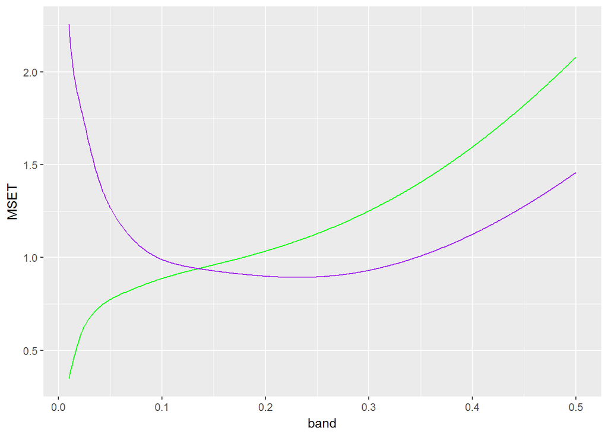

```r
ggplot()+geom_line(mapping = aes(x=band, y=MSET),col="green")+
  geom_line(mapping = aes(x=band, y=MSETEST), col="purple")
```

## TASK 3B: Privacy regulation compliance in France

We upload the needed packages.

```r
library(dplyr)
```

#### Step 1: *Import the CNIL dataset from the Open Data Portal. (1 point)*

```r
SIREN <- read.csv(choose.files(), header = T, sep = ";", dec = ".")
```

#### Step 2: *Show a (nice) table with the number of organizations that has nominated a CNIL per department. HINT : A department in France is uniquely identified by the first two digits of the postcode. (1 point)*

We only take the 2 first numbers of the “code postal” of the firms and we transform them in factors. Then, by doing *summary*, we count the numbers of firms by department.

```r
dep <- substr(SIREN$CODPOS ,start = 1,stop = 2)
dep <- as.factor(dep)
NiceTable <- data.frame(summary(dep))
NiceTable
```

```
##      summary.dep.
## 10             52
## 11            117
## 12             82
## 13            445
## 14            127
## 15             19
## 16             41
## 17            163
## 18             51
## 19             58
## 20             79
## 21            106
## 22            111
## 23             36
```

[output cut: 75 more lines]

#### Step 3: *Merge the information from the SIREN dataset into the CNIL data. Explain the method you use. HINT : In the SIREN dataset, there are some rows that refer to the same SIREN number, use the most up to date information about each company. (2 points)*

We found a way to open the big data:

```r
library(ff)
CNIL2 <- read.csv.ffdf(file=file.choose(), header=TRUE, VERBOSE=TRUE, first.rows=1000000, next.rows=1000000, nrows=4000000 colClasses=NA)
CNIL3 <- read.csv.ffdf(file=file.choose(), header=TRUE, VERBOSE=TRUE, first.rows=1000000,next.rows=1000000, skip=4000000, nrows=8000000, colClasses=NA)
CNIL4 <- read.csv.ffdf(file=file.choose(), header=TRUE, VERBOSE=TRUE, first.rows=1000000,next.rows=1000000, skip=8000000, colClasses=NA)
```

But it took too much time so we had to find another way to open and use it.

We decided to open only the 500 000 first rows of the data in order to do the computations. We also need to clean the SIREN data in order to have the same columns in SIREN and in CNIL.

```r
system.time(CNIL <- read.csv(choose.files(), sep=";", dec=".", header = T, skip = 0, nrows = 500000))
```

```
##    user  system elapsed
##   72.03    1.08   75.86
```

```r
CNIL <- CNIL[!duplicated(CNIL$SIREN),]

SIREN <- SIREN[,-118]
SIREN <- SIREN[,-117]
SIREN <- SIREN[,-116]
SIREN <- SIREN[,-115]
SIREN <- SIREN[,-114]
SIREN <- SIREN[,-113]
SIREN <- SIREN[,-112]
SIREN <- SIREN[,-111]
SIREN <- SIREN[,-110]
SIREN <- SIREN[,-109]
SIREN <- SIREN[,-108]
SIREN <- SIREN[,-107]
SIREN <- SIREN[,-106]
SIREN <- SIREN[,-105]
SIREN <- SIREN[,-104]
SIREN <- SIREN[,-103]
SIREN <- SIREN[,-102]
SIREN <- SIREN[,-101]
```

We select the lines of SIREN which have the same siren as in CNIL, we then delete their “twin” rows in CNIL and replace them by the one of SIREN to update the CNIL data.

```r
CNILindex <- SIREN[SIREN$SIREN %in% CNIL$SIREN,]
CNIL <- CNIL[-(CNIL$SIREN %in% SIREN$SIREN),]
CNIL3 <- rbind(CNIL, CNILindex)
```

Here is the code to continue for all the data but it takes a lot of time, this is why we do not run it.

```r
CNIL2 <- read.csv(choose.files(), sep=";", dec=".", header = T, skip = 500000, nrows = 1000000)
CNIL2 <- CNIL2[!duplicated(CNIL2$SIREN),]
CNILindex <- SIREN[SIREN$SIREN %in% CNIL2$SIREN,]
CNIL2 <- CNIL2[-(CNIL2$SIREN %in% SIREN$SIREN),]
CNILf2 <- rbind(CNIL2, CNILindex)

CNIL3 <- read.csv(choose.files(), sep=";", dec=".", header = T, skip = 1500000, nrows = 1000000)
CNIL3 <- CNIL3[!duplicated(CNIL3$SIREN),]
CNILindex <- SIREN[SIREN$SIREN %in% CNIL3$SIREN,]
CNIL3 <- CNIL3[-(CNIL3$SIREN %in% SIREN$SIREN),]
CNILf3 <- rbind(CNIL3, CNILindex)

CNIL4 <- read.csv(choose.files(), sep=";", dec=".", header = T, skip = 2500000, nrows = 1000000)
CNIL4 <- CNIL4[!duplicated(CNIL4$SIREN),]
CNILindex <- SIREN[SIREN$SIREN %in% CNIL4$SIREN,]
CNIL4 <- CNIL4[-(CNIL4$SIREN %in% SIREN$SIREN),]
CNILf4 <- rbind(CNIL4, CNILindex)

CNIL5 <- read.csv(choose.files(), sep=";", dec=".", header = T, skip = 3500000, nrows = 1000000)
CNIL5 <- CNIL5[!duplicated(CNIL5$SIREN),]
CNILindex <- SIREN[SIREN$SIREN %in% CNIL5$SIREN,]
CNIL5 <- CNIL5[-(CNIL5$SIREN %in% SIREN$SIREN),]
CNILf5 <- rbind(CNIL5, CNILindex)

CNIL6 <- read.csv(choose.files(), sep=";", dec=".", header = T, skip = 4500000, nrows = 1000000)
CNIL6 <- CNIL6[!duplicated(CNIL6$SIREN),]
CNILindex <- SIREN[SIREN$SIREN %in% CNIL6$SIREN,]
CNIL6 <- CNIL6[-(CNIL6$SIREN %in% SIREN$SIREN),]
CNILf6 <- rbind(CNIL6, CNILindex)

CNIL7 <- read.csv(choose.files(), sep=";", dec=".", header = T, skip = 5500000, nrows = 1000000)
CNIL7 <- CNIL7[!duplicated(CNIL7$SIREN),]
CNILindex <- SIREN[SIREN$SIREN %in% CNIL7$SIREN,]
CNIL7 <- CNIL7[-(CNIL7$SIREN %in% SIREN$SIREN),]
CNILf7 <- rbind(CNIL7, CNILindex)

CNIL8 <- read.csv(choose.files(), sep=";", dec=".", header = T, skip = 6500000, nrows = 1000000)
CNIL8 <- CNIL8[!duplicated(CNIL8$SIREN),]
CNILindex <- SIREN[SIREN$SIREN %in% CNIL8$SIREN,]
CNIL8 <- CNIL8[-(CNIL8$SIREN %in% SIREN$SIREN),]
CNILf8 <- rbind(CNIL8, CNILindex)

CNIL9 <- read.csv(choose.files(), sep=";", dec=".", header = T, skip = 7500000, nrows = 1000000)
CNIL9 <- CNIL9[!duplicated(CNIL9$SIREN),]
CNILindex <- SIREN[SIREN$SIREN %in% CNIL9$SIREN,]
CNIL9 <- CNIL9[-(CNIL9$SIREN %in% SIREN$SIREN),]
CNILf9 <- rbind(CNIL9, CNILindex)

CNIL10 <- read.csv(choose.files(), sep=";", dec=".", header = T, skip = 8500000, nrows = 1000000)
CNIL10 <- CNIL10[!duplicated(CNIL10$SIREN),]
CNILindex <- SIREN[SIREN$SIREN %in% CNIL10$SIREN,]
CNIL10 <- CNIL10[-(CNIL10$SIREN %in% SIREN$SIREN),]
CNILf10 <- rbind(CNIL10, CNILindex)

CNIL11 <- read.csv(choose.files(), sep=";", dec=".", header = T, skip = 9500000)
CNIL11 <- CNIL11[!duplicated(CNIL11$SIREN),]
CNILindex <- SIREN[SIREN$SIREN %in% CNIL11$SIREN,]
CNIL11 <- CNIL11[-(CNIL11$SIREN %in% SIREN$SIREN),]
CNILf11 <- rbind(CNIL11, CNILindex)
```

#### Step 4: *Plot the histogram of the size of the companies that nominated a CIL. Comment. (1 points)*

As we did not managed to open the data completely, we decided to open only the data with the rows that we need for the plot.

```r
system.time(CNIL <- read.csv(choose.files(), sep=";", dec=".", header = T, colClasses = c(NA,rep("NULL",78))))
```

```
##    user  system elapsed
##  484.20    7.11  613.09
```

```r
SIREN <- SIREN[,c("SIREN","LIBTEFEN")]
```

Then we do the plot.

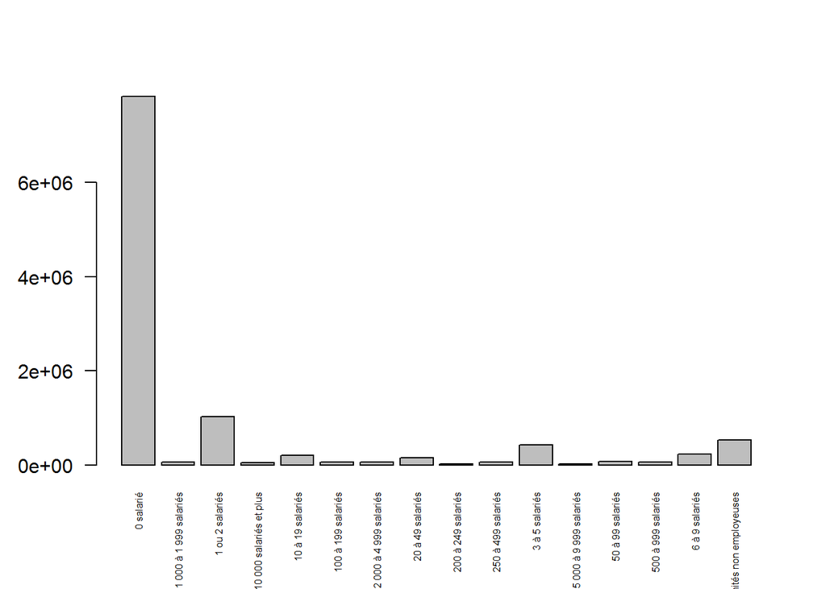

```r
plot(factor(CNIL$LIBTEFEN),las=2, cex.name=0.5)
```

The firms with 0 employees (entrepreneur) are the firms that have at most nominated the CIL.